# A Layered Grammar of Graphics

### Laura Henze<sup>1</sup>, Tristan Zook<sup>2</sup>

##### Department of Data Science; <sup>1</sup> Department of Biochemistry; <sup>2</sup> Department of Mathematics/Computer Science, Lawrence University

# Introduction

Leland Wilkinson’s *Grammar of Graphics* proposed a way to break graphics in to a set of common building blocks. Hadley Wickham’s *A Layered Grammar of Graphics* transformed data visualization by expanding on these ideas.

## From Wilkinson to Wickham

The paper extends Leland Wilkinson’s *Grammar of Graphics* by:

- Introducing a layered framework
- Embedding the grammar in R
- Creating a consistent syntax
- Making graphics easier to build and extend

This allows for high levels of control over increasingly complex graphics.

# The Grammar of Graphics

Every graphic is built from a combination of:

- Data
- Aesthetic Mappings
- Geometric Objects
- Statistical Transformations
- Scales
- Coordinate Systems
- Faceting

# Building a Plot

## The Simplest Grammar

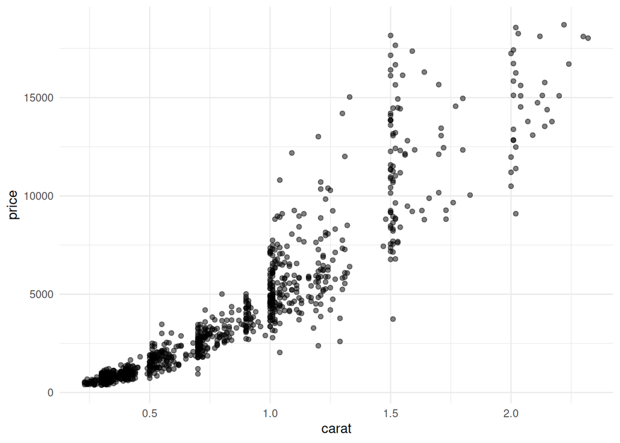

### Components

| Component | Example |
| --- | --- |
| Data | diamonds_sample |
| Aesthetics | carat to x, price to y |
| Geometry | points |
| Scale | continuous |
| Coordinates | Cartesian |

# Layers: Wickham’s Key Innovation

## Building Graphics Layer-by-Layer

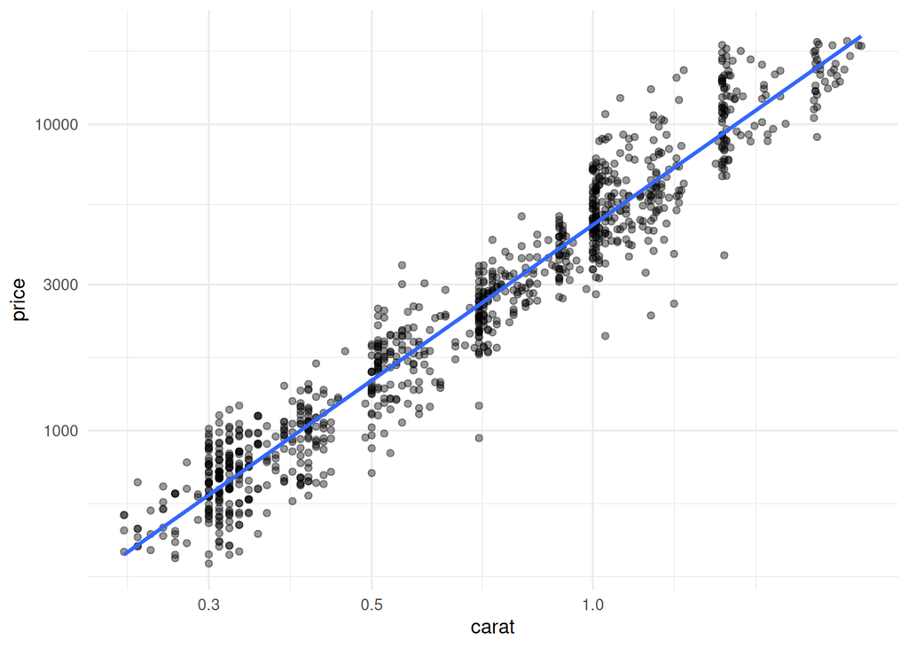

### Layers Added

1. Data
2. Point geometry
3. Statistical smoothing
4. Log-transformed scales

This example comes directly from the paper’s discussion of defaults and layering.

# Histogram = Statistic + Geometry

The power in this grammar comes from control. A histogram is a good example.

It combines:

- A binning statistic
- A bar geometry

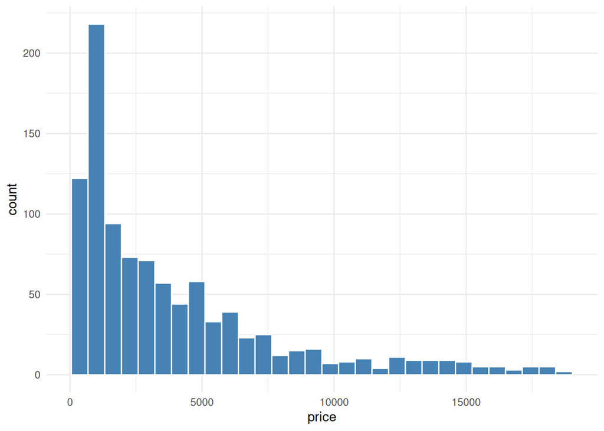

Separating statistics from geometries makes it easy to create new graphical forms.

# Coordinate Systems

## Bar Chart + Polar Coordinates = Pie Chart

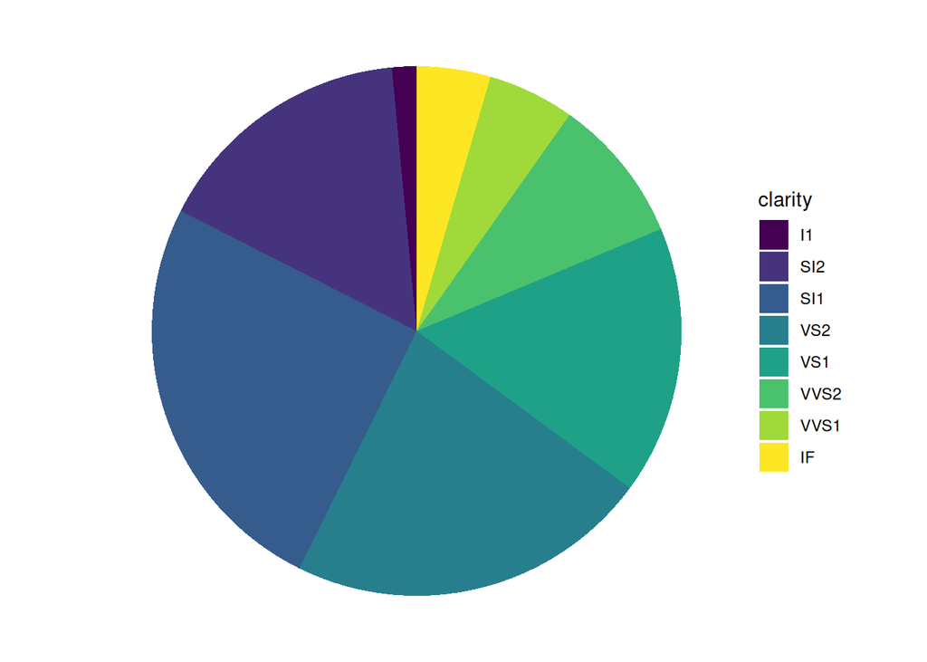

This example illustrates one of the paper’s most powerful ideas:

Changing the coordinate system can transform one graphic into another without changing the underlying data.

# Impact on Data Science

## Why This Paper Was Revolutionary

The Grammar of Graphics introduced:

- A unified framework
- Reproducible graphics
- Consistent syntax
- Extensible visualizations
- Easier communication of results

These ideas continue to influence modern visualization systems far beyond R.

# Limitations

### Challenges

- Initial learning curve
- Abstract concepts for beginners
- Some specialized graphics require extensions
- Focuses more on construction than perception

# Lasting Legacy

Today the Grammar of Graphics influences:

- ggplot2
- The tidyverse ecosystem
- Interactive visualization tools
- Data science education
- Visualization libraries in other languages

More than a decade after publication, it remains one of the most influential papers in statistical computing.

# References

Wickham, H. (2010). *A Layered Grammar of Graphics*. Journal of Computational and Graphical Statistics, 19(1), 3–28.

Wilkinson, L. (2005). *The Grammar of Graphics*. Springer.